# Sets

What is a Set in Python?

A Set in Python is an unordered collection of unique elements. Think of it as a bag where each item inside is distinct, and the way the items are arranged in the bag doesn't have any specific meaning.

Key Characteristics of Python Sets:

- Unordered: The items in a set do not have a specific order. You cannot access elements by index like you do in lists or tuples. The order can even change each time you print the same set.
- Unique Elements: Sets automatically remove duplicate items. If you try to add an element that already exists in the set, it won't be added again.
- Mutable (Changeable): You can add or remove elements from a set after it has been created.
- Heterogeneous: A set can contain items of different data types (as long as they are hashable - immutable types like numbers, strings, and tuples).
- Supports Set Operations: Sets in Python provide efficient ways to perform common mathematical set operations like union, intersection, difference, and symmetric difference.

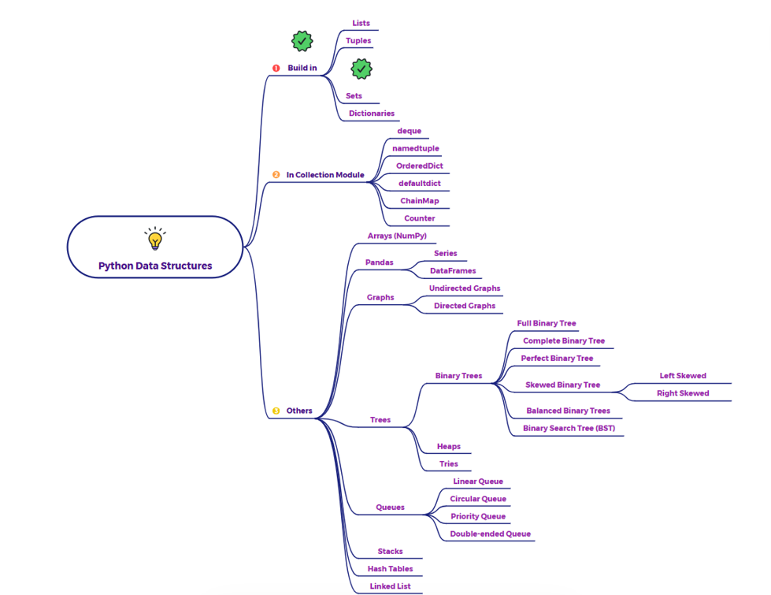

# 1. Define a Utility function to print highlighted characteristics

```python
import collections

def highlight_characteristic(name, description, symbol='='):
    """Helper function to print highlighted characteristics."""
    print(f"\n{symbol*5} {name.upper()} {symbol*5}")
    print(description)
    print(f"{symbol*5} {name.upper()} {symbol*5}\n")

print("--- Python Set Data Structure: Project Skills Example ---")
```

```
--- Python Set Data Structure: Project Skills Example ---
```

# 2. Exploring the UnOrdered nature of Sets

Unordered:

- project_skills_alpha and project_skills_beta are created with the same elements but in different literal order. They are == True when compared, demonstrating that order doesn't matter for set equality.
- An attempt to access an element by index (project_skills_alpha[0]) results in a TypeError, proving that sets do not support indexing.

```python
# 1. Unordered Characteristic

highlight_characteristic(
    "Unordered",
    "Elements in a set do not have a defined order. You cannot access elements by index or slice them."
)

project_skills_alpha = {"Python", "SQL", "Cloud Computing", "Machine Learning", "Data Visualization"}
project_skills_beta = {"Cloud Computing", "Data Visualization", "SQL", "Python", "Machine Learning"}

print(f"Project Alpha Skills: {project_skills_alpha}")
print(f"Project Beta Skills (same elements, different literal order): {project_skills_beta}")
print(f"Are they considered equal? {project_skills_alpha == project_skills_beta}") # True, because order doesn't matter for equality

# Attempting to access by index (will cause an error)
try:
    print(f"Attempting to access element at index 0: {project_skills_alpha[0]}")
except TypeError as e:
    print(f"Error caught as expected: {e}")
    print("This confirms sets are unordered and do not support indexing.\n")
```

```
===== UNORDERED =====
Elements in a set do not have a defined order. You cannot access elements by index or slice them.
===== UNORDERED =====

Project Alpha Skills: {'Python', 'SQL', 'Cloud Computing', 'Data Visualization', 'Machine Learning'}
Project Beta Skills (same elements, different literal order): {'Python', 'SQL', 'Cloud Computing', 'Data Visualization', 'Machine Learning'}
Are they considered equal? True
Error caught as expected: 'set' object is not subscriptable
This confirms sets are unordered and do not support indexing.
```

# 3. Exploring the Unique Elements nature of Sets

Unique Elements:

- When team_member_skills is initialized with {"Python", "SQL", "Python", "Java", "SQL", "Agile"}, the output {'Agile', 'Java', 'Python', 'SQL'} clearly shows that Python and SQL appear only once, as duplicates are automatically discarded.
- Attempting to add() an element already present in the set (e.g., "SQL") has no effect on the set's contents or size, further demonstrating uniqueness.

```python
# 2. Unique Elements Characteristic

highlight_characteristic(
    "Unique Elements",
    "A set automatically ensures that all its elements are unique. Duplicate elements are automatically removed."
)

# Trying to create a set with duplicates
team_member_skills = {"Python", "SQL", "Python", "Java", "SQL", "Agile"}
print(f"Skills provided (with duplicates): Python, SQL, Python, Java, SQL, Agile")
print(f"Set of skills created from input: {team_member_skills}")
print(f"Note how 'Python' and 'SQL' only appear once, confirming uniqueness.")

# Adding a duplicate element to an existing set
print(f"Current unique skills: {team_member_skills}")
team_member_skills.add("SQL") # Adding an element already present
print(f"After attempting to add 'SQL' again: {team_member_skills} (No change)")
print(f"Size of set: {len(team_member_skills)}") # Size remains the same
```

```
===== UNIQUE ELEMENTS =====
A set automatically ensures that all its elements are unique. Duplicate elements are automatically removed.
===== UNIQUE ELEMENTS =====

Skills provided (with duplicates): Python, SQL, Python, Java, SQL, Agile
Set of skills created from input: {'SQL', 'Java', 'Python', 'Agile'}
Note how 'Python' and 'SQL' only appear once, confirming uniqueness.
Current unique skills: {'SQL', 'Java', 'Python', 'Agile'}
After attempting to add 'SQL' again: {'SQL', 'Java', 'Python', 'Agile'} (No change)
Size of set: 4
```

# 4. Exploring Mutable nature in Sets

Mutable:

- team_member_skills.add("Docker") demonstrates adding a new element.
- team_member_skills.remove("Java") and team_member_skills.discard("Agile") show how elements can be removed from the set.
- team_member_skills.clear() removes all elements, leaving an empty set. This confirms that the set itself can be modified after creation.

```python
# 3. Mutable Characteristic

highlight_characteristic(
    "Mutable",
    "Sets can be changed after creation: elements can be added or removed. (However, individual elements cannot be modified in-place)."
)

print(f"Current team member skills: {team_member_skills}")

# Adding a new skill
team_member_skills.add("Docker")
print(f"After adding 'Docker': {team_member_skills}")

# Removing a skill
team_member_skills.remove("Java") # Using remove()
print(f"After removing 'Java': {team_member_skills}")

team_member_skills.discard("Agile") # Using discard()
print(f"After discarding 'Agile': {team_member_skills}")

# Clear the set
team_member_skills.clear()
print(f"After clearing the set: {team_member_skills} (Empty set)")
```

```
===== MUTABLE =====
Sets can be changed after creation: elements can be added or removed. (However, individual elements cannot be modified in-place).
===== MUTABLE =====

Current team member skills: {'SQL', 'Java', 'Python', 'Agile'}
After adding 'Docker': {'Agile', 'Docker', 'Python', 'SQL', 'Java'}
After removing 'Java': {'Agile', 'Docker', 'Python', 'SQL'}
After discarding 'Agile': {'Docker', 'Python', 'SQL'}
After clearing the set: set() (Empty set)
```

# 5. Exploring Heterogeneous Characteristics of Sets

Heterogeneous:

- The mixed_requirements set contains elements of different data types: str, int, float, bool, and even an immutable tuple.
- A comment highlights that mutable types like list or dict cannot be directly stored as elements in a set because set elements must be "hashable."

```python
# 4. Heterogeneous Characteristic

highlight_characteristic(
    "Heterogeneous",
    "A set can store elements of different, hashable data types."
)

# A set representing mixed project requirements/metadata
mixed_requirements = {
    "Backend Development", # String
    2025,                  # Integer (e.g., target year)
    3.14,                  # Float (e.g., version number)
    True,                  # Boolean (e.g., is critical task?)
    ("API Design", "Security"), # Tuple (immutable, hence hashable)
    # Note: Lists and dictionaries are mutable, so they cannot be elements of a set directly.
    # {"framework": "React"} # This would cause a TypeError
}
print(f"Mixed requirements set: {mixed_requirements}")
print(f"Type of element '2025': {type(2025)}")
print(f"Type of element ('API Design', 'Security'): {type(('API Design', 'Security'))}\n")
```

```
===== HETEROGENEOUS =====
A set can store elements of different, hashable data types.
===== HETEROGENEOUS =====

Mixed requirements set: {True, 3.14, 'Backend Development', 2025, ('API Design', 'Security')}
Type of element '2025': <class 'int'>
Type of element ('API Design', 'Security'): <class 'tuple'>
```

# 6. Exploring Set operations in Sets

Supports Set Operations:

- The example showcases several common set operations using both method calls (.union(), .intersection(), .difference(), .symmetric_difference(), .issubset(), .issuperset()) and their corresponding operator shortcuts (|, &, -, ^).
- These operations demonstrate how sets are powerful for comparing and combining collections of unique items, which is very useful in scenarios like comparing skill sets, finding commonalities, or identifying gaps.

```python
# 5. Supports Set Operations Characteristic

highlight_characteristic(
    "Supports Set Operations",
    "Sets provide powerful methods for mathematical set operations like union, intersection, difference, and symmetric difference."
)

team_alpha_skills = {"Python", "SQL", "Cloud Computing", "Leadership", "Project Management"}
team_beta_skills = {"Java", "SQL", "Machine Learning", "Cloud Computing", "DevOps"}
project_needs = {"Python", "Machine Learning", "Data Visualization", "Cloud Computing", "Agile"}

print(f"Team Alpha Skills: {team_alpha_skills}")
print(f"Team Beta Skills: {team_beta_skills}")
print(f"Project Needs: {project_needs}\n")

# Union: All skills from both teams
all_team_skills = team_alpha_skills.union(team_beta_skills)
print(f"Union (All skills from both teams): {all_team_skills}")
print(f"Using '|' operator: {team_alpha_skills | team_beta_skills}\n")

# Intersection: Common skills between the two teams
common_skills = team_alpha_skills.intersection(team_beta_skills)
print(f"Intersection (Common skills between teams): {common_skills}")
print(f"Using '&' operator: {team_alpha_skills & team_beta_skills}\n")

# Difference: Skills Team Alpha has that Team Beta does NOT have
alpha_only_skills = team_alpha_skills.difference(team_beta_skills)
print(f"Difference (Skills Alpha has, Beta does not): {alpha_only_skills}")
print(f"Using '-' operator: {team_alpha_skills - team_beta_skills}\n")

# Symmetric Difference: Skills that are in either set, but not in their intersection (unique to each)
unique_to_each_team = team_alpha_skills.symmetric_difference(team_beta_skills)
print(f"Symmetric Difference (Skills unique to each team): {unique_to_each_team}")
print(f"Using '^' operator: {team_alpha_skills ^ team_beta_skills}\n")

# Subset: Is Team Alpha's skills a subset of Project Needs?
is_subset = team_alpha_skills.issubset(project_needs)
print(f"Is Team Alpha's skills a subset of Project Needs? {is_subset}")
print(f"('Leadership' and 'Project Management' in Alpha are not in Project Needs)\n")

# Superset: Does Project Needs include all of Team Beta's skills?
is_superset = project_needs.issuperset(team_beta_skills)
print(f"Does Project Needs include all of Team Beta's skills? {is_superset}")
print(f"('Java' and 'DevOps' in Beta are not in Project Needs)\n")

# Finding missing skills for a project:
missing_project_skills_from_alpha = project_needs.difference(team_alpha_skills)
print(f"Project skills missing from Team Alpha: {missing_project_skills_from_alpha}")
```

```
===== SUPPORTS SET OPERATIONS =====
Sets provide powerful methods for mathematical set operations like union, intersection, difference, and symmetric difference.
===== SUPPORTS SET OPERATIONS =====

Team Alpha Skills: {'Leadership', 'Python', 'SQL', 'Cloud Computing', 'Project Management'}
Team Beta Skills: {'DevOps', 'SQL', 'Cloud Computing', 'Java', 'Machine Learning'}
Project Needs: {'Python', 'Cloud Computing', 'Data Visualization', 'Machine Learning', 'Agile'}

Union (All skills from both teams): {'Leadership', 'DevOps', 'Machine Learning', 'Python', 'SQL', 'Cloud Computing', 'Java', 'Project Management'}
Using '|' operator: {'Leadership', 'DevOps', 'Machine Learning', 'Python', 'SQL', 'Cloud Computing', 'Java', 'Project Management'}

Intersection (Common skills between teams): {'SQL', 'Cloud Computing'}
Using '&' operator: {'SQL', 'Cloud Computing'}

Difference (Skills Alpha has, Beta does not): {'Leadership', 'Project Management', 'Python'}
Using '-' operator: {'Leadership', 'Project Management', 'Python'}

Symmetric Difference (Skills unique to each team): {'DevOps', 'Leadership', 'Python', 'Java', 'Machine Learning', 'Project Management'}
Using '^' operator: {'DevOps', 'Leadership', 'Python', 'Java', 'Machine Learning', 'Project Management'}

Is Team Alpha's skills a subset of Project Needs? False
('Leadership' and 'Project Management' in Alpha are not in Project Needs)

Does Project Needs include all of Team Beta's skills? False
('Java' and 'DevOps' in Beta are not in Project Needs)

Project skills missing from Team Alpha: {'Data Visualization', 'Machine Learning', 'Agile'}
```